# Optimal Treatment Analysis

## Outcome Variable

**Outcome Variable:** haz

## Predictor Variables

**Intervention Variable:** nrooms

**Adjustment Set:**

- arm
- sex
- W_mage
- meducyrs
- feducyrs
- hhwealth_quart
- hfoodsec
- W_mhtcm
- W_nchldlt5
- W_parity
- impfloor
- impsan
- safeh20
- delta_W_mage
- delta_meducyrs
- delta_feducyrs
- delta_hhwealth_quart
- delta_hfoodsec
- delta_W_mhtcm
- delta_W_nchldlt5
- delta_W_parity
- delta_impfloor
- delta_impsan
- delta_safeh20

## Stratifying Variables

The analysis was stratified on these variable(s):

- agecat
- studyid
- country

## Data Summary

| agecat | studyid | country | nrooms | n_cell | n |
| --- | --- | --- | --- | --- | --- |
| Birth | ki0047075b-MAL-ED | BANGLADESH | 4+ | 12 | 234 |
| Birth | ki0047075b-MAL-ED | BANGLADESH | 1 | 144 | 234 |
| Birth | ki0047075b-MAL-ED | BANGLADESH | 2 | 50 | 234 |
| Birth | ki0047075b-MAL-ED | BANGLADESH | 3 | 28 | 234 |
| Birth | ki0047075b-MAL-ED | BRAZIL | 4+ | 102 | 174 |
| Birth | ki0047075b-MAL-ED | BRAZIL | 1 | 3 | 174 |
| Birth | ki0047075b-MAL-ED | BRAZIL | 2 | 19 | 174 |
| Birth | ki0047075b-MAL-ED | BRAZIL | 3 | 50 | 174 |
| Birth | ki0047075b-MAL-ED | INDIA | 4+ | 22 | 191 |
| Birth | ki0047075b-MAL-ED | INDIA | 1 | 69 | 191 |
| Birth | ki0047075b-MAL-ED | INDIA | 2 | 68 | 191 |
| Birth | ki0047075b-MAL-ED | INDIA | 3 | 32 | 191 |
| Birth | ki0047075b-MAL-ED | NEPAL | 4+ | 97 | 171 |
| Birth | ki0047075b-MAL-ED | NEPAL | 1 | 36 | 171 |
| Birth | ki0047075b-MAL-ED | NEPAL | 2 | 21 | 171 |
| Birth | ki0047075b-MAL-ED | NEPAL | 3 | 17 | 171 |
| Birth | ki0047075b-MAL-ED | PERU | 4+ | 132 | 259 |
| Birth | ki0047075b-MAL-ED | PERU | 1 | 17 | 259 |
| Birth | ki0047075b-MAL-ED | PERU | 2 | 51 | 259 |
| Birth | ki0047075b-MAL-ED | PERU | 3 | 59 | 259 |
| Birth | ki0047075b-MAL-ED | SOUTH AFRICA | 4+ | 160 | 218 |
| Birth | ki0047075b-MAL-ED | SOUTH AFRICA | 1 | 14 | 218 |
| Birth | ki0047075b-MAL-ED | SOUTH AFRICA | 2 | 21 | 218 |
| Birth | ki0047075b-MAL-ED | SOUTH AFRICA | 3 | 23 | 218 |
| Birth | ki0047075b-MAL-ED | TANZANIA, UNITED REPUBLIC OF | 4+ | 55 | 118 |
| Birth | ki0047075b-MAL-ED | TANZANIA, UNITED REPUBLIC OF | 1 | 6 | 118 |
| Birth | ki0047075b-MAL-ED | TANZANIA, UNITED REPUBLIC OF | 2 | 24 | 118 |
| Birth | ki0047075b-MAL-ED | TANZANIA, UNITED REPUBLIC OF | 3 | 33 | 118 |
| Birth | ki1000108-CMC-V-BCS-2002 | INDIA | 4+ | 5 | 90 |
| Birth | ki1000108-CMC-V-BCS-2002 | INDIA | 1 | 38 | 90 |

[output cut: 154 more lines]

The following strata were considered:

- agecat: 24 months, studyid: ki0047075b-MAL-ED, country: BANGLADESH
- agecat: 24 months, studyid: ki0047075b-MAL-ED, country: BRAZIL
- agecat: 24 months, studyid: ki0047075b-MAL-ED, country: INDIA
- agecat: 24 months, studyid: ki0047075b-MAL-ED, country: NEPAL
- agecat: 24 months, studyid: ki0047075b-MAL-ED, country: PERU
- agecat: 24 months, studyid: ki0047075b-MAL-ED, country: SOUTH AFRICA
- agecat: 24 months, studyid: ki0047075b-MAL-ED, country: TANZANIA, UNITED REPUBLIC OF
- agecat: 24 months, studyid: ki1000108-CMC-V-BCS-2002, country: INDIA
- agecat: 24 months, studyid: ki1000108-IRC, country: INDIA
- agecat: 24 months, studyid: ki1017093b-PROVIDE, country: BANGLADESH
- agecat: 24 months, studyid: ki1017093c-NIH-Crypto, country: BANGLADESH
- agecat: 24 months, studyid: ki1113344-GMS-Nepal, country: NEPAL
- agecat: 24 months, studyid: ki1114097-CONTENT, country: PERU
- agecat: 24 months, studyid: ki1135781-COHORTS, country: INDIA
- agecat: 24 months, studyid: kiGH5241-JiVitA-3, country: BANGLADESH
- agecat: 24 months, studyid: kiGH5241-JiVitA-4, country: BANGLADESH
- agecat: 6 months, studyid: ki0047075b-MAL-ED, country: BANGLADESH
- agecat: 6 months, studyid: ki0047075b-MAL-ED, country: BRAZIL
- agecat: 6 months, studyid: ki0047075b-MAL-ED, country: INDIA
- agecat: 6 months, studyid: ki0047075b-MAL-ED, country: NEPAL
- agecat: 6 months, studyid: ki0047075b-MAL-ED, country: PERU
- agecat: 6 months, studyid: ki0047075b-MAL-ED, country: SOUTH AFRICA
- agecat: 6 months, studyid: ki0047075b-MAL-ED, country: TANZANIA, UNITED REPUBLIC OF
- agecat: 6 months, studyid: ki1000108-CMC-V-BCS-2002, country: INDIA
- agecat: 6 months, studyid: ki1000108-IRC, country: INDIA
- agecat: 6 months, studyid: ki1017093b-PROVIDE, country: BANGLADESH
- agecat: 6 months, studyid: ki1017093c-NIH-Crypto, country: BANGLADESH
- agecat: 6 months, studyid: ki1113344-GMS-Nepal, country: NEPAL
- agecat: 6 months, studyid: ki1114097-CONTENT, country: PERU
- agecat: 6 months, studyid: ki1135781-COHORTS, country: INDIA
- agecat: 6 months, studyid: kiGH5241-JiVitA-3, country: BANGLADESH
- agecat: 6 months, studyid: kiGH5241-JiVitA-4, country: BANGLADESH
- agecat: Birth, studyid: ki0047075b-MAL-ED, country: BANGLADESH
- agecat: Birth, studyid: ki0047075b-MAL-ED, country: BRAZIL
- agecat: Birth, studyid: ki0047075b-MAL-ED, country: INDIA
- agecat: Birth, studyid: ki0047075b-MAL-ED, country: NEPAL
- agecat: Birth, studyid: ki0047075b-MAL-ED, country: PERU
- agecat: Birth, studyid: ki0047075b-MAL-ED, country: SOUTH AFRICA
- agecat: Birth, studyid: ki0047075b-MAL-ED, country: TANZANIA, UNITED REPUBLIC OF
- agecat: Birth, studyid: ki1000108-CMC-V-BCS-2002, country: INDIA
- agecat: Birth, studyid: ki1000108-IRC, country: INDIA
- agecat: Birth, studyid: ki1017093c-NIH-Crypto, country: BANGLADESH
- agecat: Birth, studyid: ki1114097-CONTENT, country: PERU
- agecat: Birth, studyid: ki1135781-COHORTS, country: INDIA
- agecat: Birth, studyid: kiGH5241-JiVitA-3, country: BANGLADESH
- agecat: Birth, studyid: kiGH5241-JiVitA-4, country: BANGLADESH

### Dropped Strata

- agecat: Birth, studyid: ki0047075b-MAL-ED, country: BRAZIL
- agecat: Birth, studyid: ki1017093c-NIH-Crypto, country: BANGLADESH
- agecat: Birth, studyid: ki1114097-CONTENT, country: PERU
- agecat: 6 months, studyid: ki0047075b-MAL-ED, country: BRAZIL
- agecat: 24 months, studyid: ki0047075b-MAL-ED, country: BRAZIL

## Methods Detail

We’re interested in the causal parameters $E[Y_a]$ for all values of $a \in \mathcal{A}$. These parameters represent the mean outcome if, possibly contrary to fact, we intervened to set all units to have $A=a$. Under the randomization and positivity assumptions, these are identified by the statistical parameters $\psi_a=E_W[E_{Y|A,W}(Y|A=a,W)]$. In addition, we’re interested in the mean of $Y$, $E[Y]$ under no intervention (the observed mean). We will estimate these parameters by using SuperLearner to fit the relevant likelihood factors – $E_{Y|A,W}(Y|A=a,W)$ and $p(A=a|W)$, and then updating our likelihood fit using a joint TMLE.

For unadjusted analyses ($W=\{\}$), initial likelihoods were estimated using Lrnr_glm to estimate the simple $E(Y|A)$ and Lrnr_mean to estimate $p(A)$. For adjusted analyses, a small library containing Lrnr_glmnet, Lrnr_xgboost, and Lrnr_mean was used.

Having estimated these parameters, we will then use the delta method to estimate relative risks and attributable risks relative to a prespecified baseline level of $A$.

# Results Detail

## Results Plots

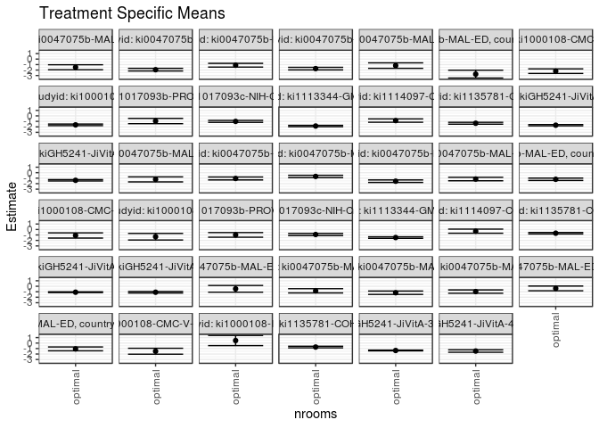

## Results Table

### Parameter: TSM

| agecat | studyid | country | intervention_level | baseline_level | estimate | ci_lower | ci_upper |
| --- | --- | --- | --- | --- | --- | --- | --- |
| Birth | ki0047075b-MAL-ED | BANGLADESH | optimal | observed | -0.4673404 | -1.0800870 | 0.1454062 |
| Birth | ki0047075b-MAL-ED | INDIA | optimal | observed | -0.8287695 | -1.2156321 | -0.4419068 |
| Birth | ki0047075b-MAL-ED | NEPAL | optimal | observed | -1.1772045 | -1.4846572 | -0.8697519 |
| Birth | ki0047075b-MAL-ED | PERU | optimal | observed | -0.9681069 | -1.2738201 | -0.6623937 |
| Birth | ki0047075b-MAL-ED | SOUTH AFRICA | optimal | observed | -0.3883248 | -0.8191044 | 0.0424547 |
| Birth | ki0047075b-MAL-ED | TANZANIA, UNITED REPUBLIC OF | optimal | observed | -1.0621221 | -1.4164369 | -0.7078073 |
| Birth | ki1000108-CMC-V-BCS-2002 | INDIA | optimal | observed | -1.4902795 | -2.0305986 | -0.9499605 |
| Birth | ki1000108-IRC | INDIA | optimal | observed | 0.4583986 | -0.4648787 | 1.3816760 |
| Birth | ki1135781-COHORTS | INDIA | optimal | observed | -0.7277971 | -0.8741098 | -0.5814845 |
| Birth | kiGH5241-JiVitA-3 | BANGLADESH | optimal | observed | -1.3547685 | -1.4268435 | -1.2826936 |
| Birth | kiGH5241-JiVitA-4 | BANGLADESH | optimal | observed | -1.4540770 | -1.6757339 | -1.2324201 |
| 6 months | ki0047075b-MAL-ED | BANGLADESH | optimal | observed | -1.2228095 | -1.6814920 | -0.7641270 |
| 6 months | ki0047075b-MAL-ED | INDIA | optimal | observed | -1.0532855 | -1.3216270 | -0.7849441 |
| 6 months | ki0047075b-MAL-ED | NEPAL | optimal | observed | -0.6849412 | -0.8997538 | -0.4701285 |
| 6 months | ki0047075b-MAL-ED | PERU | optimal | observed | -1.5507516 | -1.7774947 | -1.3240085 |
| 6 months | ki0047075b-MAL-ED | SOUTH AFRICA | optimal | observed | -1.1587947 | -1.4766381 | -0.8409514 |
| 6 months | ki0047075b-MAL-ED | TANZANIA, UNITED REPUBLIC OF | optimal | observed | -1.2040565 | -1.4203687 | -0.9877443 |
| 6 months | ki1000108-CMC-V-BCS-2002 | INDIA | optimal | observed | -1.0929888 | -1.5702556 | -0.6157220 |
| 6 months | ki1000108-IRC | INDIA | optimal | observed | -1.3185404 | -1.9177637 | -0.7193170 |
| 6 months | ki1017093b-PROVIDE | BANGLADESH | optimal | observed | -0.9899415 | -1.4112331 | -0.5686498 |
| 6 months | ki1017093c-NIH-Crypto | BANGLADESH | optimal | observed | -0.9168359 | -1.1136653 | -0.7200065 |
| 6 months | ki1113344-GMS-Nepal | NEPAL | optimal | observed | -1.4738439 | -1.6140004 | -1.3336874 |
| 6 months | ki1114097-CONTENT | PERU | optimal | observed | -0.3113132 | -0.6858153 | 0.0631889 |
| 6 months | ki1135781-COHORTS | INDIA | optimal | observed | -0.6770028 | -0.8096966 | -0.5443090 |
| 6 months | kiGH5241-JiVitA-3 | BANGLADESH | optimal | observed | -1.0816790 | -1.1565110 | -1.0068470 |
| 6 months | kiGH5241-JiVitA-4 | BANGLADESH | optimal | observed | -1.0866423 | -1.2283117 | -0.9449729 |
| 24 months | ki0047075b-MAL-ED | BANGLADESH | optimal | observed | -1.4898291 | -1.9471923 | -1.0324660 |
| 24 months | ki0047075b-MAL-ED | INDIA | optimal | observed | -1.9331232 | -2.1755558 | -1.6906905 |
| 24 months | ki0047075b-MAL-ED | NEPAL | optimal | observed | -1.1181840 | -1.4572628 | -0.7791052 |
| 24 months | ki0047075b-MAL-ED | PERU | optimal | observed | -1.7367335 | -1.9739806 | -1.4994865 |
| 24 months | ki0047075b-MAL-ED | SOUTH AFRICA | optimal | observed | -1.1841728 | -1.6837097 | -0.6846358 |
| 24 months | ki0047075b-MAL-ED | TANZANIA, UNITED REPUBLIC OF | optimal | observed | -2.7429239 | -3.4549540 | -2.0308938 |
| 24 months | ki1000108-CMC-V-BCS-2002 | INDIA | optimal | observed | -2.1989946 | -2.6173240 | -1.7806653 |
| 24 months | ki1000108-IRC | INDIA | optimal | observed | -1.6361280 | -1.7814898 | -1.4907661 |
| 24 months | ki1017093b-PROVIDE | BANGLADESH | optimal | observed | -0.9400604 | -1.4184474 | -0.4616734 |
| 24 months | ki1017093c-NIH-Crypto | BANGLADESH | optimal | observed | -1.0040327 | -1.1836206 | -0.8244448 |
| 24 months | ki1113344-GMS-Nepal | NEPAL | optimal | observed | -1.8483424 | -1.9680892 | -1.7285956 |
| 24 months | ki1114097-CONTENT | PERU | optimal | observed | -0.8547409 | -1.1572932 | -0.5521885 |
| 24 months | ki1135781-COHORTS | INDIA | optimal | observed | -1.3410843 | -1.5139285 | -1.1682401 |
| 24 months | kiGH5241-JiVitA-3 | BANGLADESH | optimal | observed | -1.6967220 | -1.8091192 | -1.5843249 |
| 24 months | kiGH5241-JiVitA-4 | BANGLADESH | optimal | observed | -1.3905226 | -1.5154341 | -1.2656111 |

### Parameter: E(Y)

| agecat | studyid | country | intervention_level | baseline_level | estimate | ci_lower | ci_upper |
| --- | --- | --- | --- | --- | --- | --- | --- |
| Birth | ki0047075b-MAL-ED | BANGLADESH | observed | observed | -1.0229487 | -1.1509575 | -0.8949400 |
| Birth | ki0047075b-MAL-ED | INDIA | observed | observed | -1.0069634 | -1.1525107 | -0.8614160 |
| Birth | ki0047075b-MAL-ED | NEPAL | observed | observed | -0.6998830 | -0.8579049 | -0.5418612 |
| Birth | ki0047075b-MAL-ED | PERU | observed | observed | -0.9447876 | -1.0604945 | -0.8290808 |
| Birth | ki0047075b-MAL-ED | SOUTH AFRICA | observed | observed | -0.6917890 | -0.8248091 | -0.5587689 |
| Birth | ki0047075b-MAL-ED | TANZANIA, UNITED REPUBLIC OF | observed | observed | -0.8810169 | -1.0869236 | -0.6751103 |
| Birth | ki1000108-CMC-V-BCS-2002 | INDIA | observed | observed | -0.9654444 | -1.1742112 | -0.7566777 |
| Birth | ki1000108-IRC | INDIA | observed | observed | -0.3079016 | -0.4694769 | -0.1463262 |
| Birth | ki1135781-COHORTS | INDIA | observed | observed | -0.6777626 | -0.7107167 | -0.6448086 |
| Birth | kiGH5241-JiVitA-3 | BANGLADESH | observed | observed | -1.5751978 | -1.5949779 | -1.5554177 |
| Birth | kiGH5241-JiVitA-4 | BANGLADESH | observed | observed | -1.4976642 | -1.5817349 | -1.4135935 |
| 6 months | ki0047075b-MAL-ED | BANGLADESH | observed | observed | -1.2033681 | -1.3212429 | -1.0854932 |
| 6 months | ki0047075b-MAL-ED | INDIA | observed | observed | -1.2159433 | -1.3345235 | -1.0973630 |
| 6 months | ki0047075b-MAL-ED | NEPAL | observed | observed | -0.5610593 | -0.6737915 | -0.4483272 |
| 6 months | ki0047075b-MAL-ED | PERU | observed | observed | -1.3280247 | -1.4371552 | -1.2188942 |
| 6 months | ki0047075b-MAL-ED | SOUTH AFRICA | observed | observed | -1.0548494 | -1.1845497 | -0.9251491 |
| 6 months | ki0047075b-MAL-ED | TANZANIA, UNITED REPUBLIC OF | observed | observed | -1.3601215 | -1.4821830 | -1.2380600 |
| 6 months | ki1000108-CMC-V-BCS-2002 | INDIA | observed | observed | -1.4234508 | -1.5645974 | -1.2823042 |
| 6 months | ki1000108-IRC | INDIA | observed | observed | -1.2470123 | -1.3779341 | -1.1160906 |
| 6 months | ki1017093b-PROVIDE | BANGLADESH | observed | observed | -1.0871041 | -1.1635539 | -1.0106543 |
| 6 months | ki1017093c-NIH-Crypto | BANGLADESH | observed | observed | -1.1986783 | -1.2700937 | -1.1272630 |
| 6 months | ki1113344-GMS-Nepal | NEPAL | observed | observed | -1.3321522 | -1.4103691 | -1.2539352 |
| 6 months | ki1114097-CONTENT | PERU | observed | observed | -0.3139217 | -0.4868486 | -0.1409948 |
| 6 months | ki1135781-COHORTS | INDIA | observed | observed | -1.0413281 | -1.0740395 | -1.0086167 |
| 6 months | kiGH5241-JiVitA-3 | BANGLADESH | observed | observed | -1.3132988 | -1.3364412 | -1.2901565 |
| 6 months | kiGH5241-JiVitA-4 | BANGLADESH | observed | observed | -1.3440477 | -1.3813060 | -1.3067894 |
| 24 months | ki0047075b-MAL-ED | BANGLADESH | observed | observed | -1.9431132 | -2.0691678 | -1.8170586 |
| 24 months | ki0047075b-MAL-ED | INDIA | observed | observed | -1.8458150 | -1.9718703 | -1.7197596 |
| 24 months | ki0047075b-MAL-ED | NEPAL | observed | observed | -1.2752193 | -1.3954783 | -1.1549603 |
| 24 months | ki0047075b-MAL-ED | PERU | observed | observed | -1.7500995 | -1.8705474 | -1.6296516 |
| 24 months | ki0047075b-MAL-ED | SOUTH AFRICA | observed | observed | -1.6228361 | -1.7581177 | -1.4875546 |
| 24 months | ki0047075b-MAL-ED | TANZANIA, UNITED REPUBLIC OF | observed | observed | -2.6058879 | -2.7403043 | -2.4714714 |
| 24 months | ki1000108-CMC-V-BCS-2002 | INDIA | observed | observed | -2.5593683 | -2.6601027 | -2.4586339 |
| 24 months | ki1000108-IRC | INDIA | observed | observed | -1.7853686 | -1.8795723 | -1.6911648 |
| 24 months | ki1017093b-PROVIDE | BANGLADESH | observed | observed | -1.5861179 | -1.6693668 | -1.5028689 |
| 24 months | ki1017093c-NIH-Crypto | BANGLADESH | observed | observed | -1.4295331 | -1.5127726 | -1.3462935 |
| 24 months | ki1113344-GMS-Nepal | NEPAL | observed | observed | -1.8835905 | -1.9681499 | -1.7990312 |
| 24 months | ki1114097-CONTENT | PERU | observed | observed | -0.6962195 | -0.8674103 | -0.5250287 |
| 24 months | ki1135781-COHORTS | INDIA | observed | observed | -2.0008909 | -2.0401990 | -1.9615828 |
| 24 months | kiGH5241-JiVitA-3 | BANGLADESH | observed | observed | -2.0127436 | -2.0404564 | -1.9850309 |
| 24 months | kiGH5241-JiVitA-4 | BANGLADESH | observed | observed | -1.7578934 | -1.7933205 | -1.7224663 |

### Parameter: PAR

| agecat | studyid | country | intervention_level | baseline_level | estimate | ci_lower | ci_upper |
| --- | --- | --- | --- | --- | --- | --- | --- |
| Birth | ki0047075b-MAL-ED | BANGLADESH | optimal | observed | -0.5556083 | -1.1513301 | 0.0401134 |
| Birth | ki0047075b-MAL-ED | INDIA | optimal | observed | -0.1781939 | -0.5434223 | 0.1870345 |
| Birth | ki0047075b-MAL-ED | NEPAL | optimal | observed | 0.4773215 | 0.1920171 | 0.7626259 |
| Birth | ki0047075b-MAL-ED | PERU | optimal | observed | 0.0233193 | -0.2440374 | 0.2906760 |
| Birth | ki0047075b-MAL-ED | SOUTH AFRICA | optimal | observed | -0.3034642 | -0.7301367 | 0.1232084 |
| Birth | ki0047075b-MAL-ED | TANZANIA, UNITED REPUBLIC OF | optimal | observed | 0.1811052 | -0.1851711 | 0.5473814 |
| Birth | ki1000108-CMC-V-BCS-2002 | INDIA | optimal | observed | 0.5248351 | 0.0168600 | 1.0328102 |
| Birth | ki1000108-IRC | INDIA | optimal | observed | -0.7663002 | -1.6585873 | 0.1259869 |
| Birth | ki1135781-COHORTS | INDIA | optimal | observed | 0.0500345 | -0.0939871 | 0.1940562 |
| Birth | kiGH5241-JiVitA-3 | BANGLADESH | optimal | observed | -0.2204293 | -0.2924279 | -0.1484307 |
| Birth | kiGH5241-JiVitA-4 | BANGLADESH | optimal | observed | -0.0435872 | -0.2520131 | 0.1648386 |
| 6 months | ki0047075b-MAL-ED | BANGLADESH | optimal | observed | 0.0194414 | -0.4334556 | 0.4723385 |
| 6 months | ki0047075b-MAL-ED | INDIA | optimal | observed | -0.1626577 | -0.4107770 | 0.0854615 |
| 6 months | ki0047075b-MAL-ED | NEPAL | optimal | observed | 0.1238818 | -0.0565283 | 0.3042920 |
| 6 months | ki0047075b-MAL-ED | PERU | optimal | observed | 0.2227269 | 0.0154314 | 0.4300224 |
| 6 months | ki0047075b-MAL-ED | SOUTH AFRICA | optimal | observed | 0.1039453 | -0.2102408 | 0.4181315 |
| 6 months | ki0047075b-MAL-ED | TANZANIA, UNITED REPUBLIC OF | optimal | observed | -0.1560649 | -0.3508446 | 0.0387148 |
| 6 months | ki1000108-CMC-V-BCS-2002 | INDIA | optimal | observed | -0.3304620 | -0.7993060 | 0.1383821 |
| 6 months | ki1000108-IRC | INDIA | optimal | observed | 0.0715280 | -0.5008101 | 0.6438661 |
| 6 months | ki1017093b-PROVIDE | BANGLADESH | optimal | observed | -0.0971626 | -0.5099706 | 0.3156454 |
| 6 months | ki1017093c-NIH-Crypto | BANGLADESH | optimal | observed | -0.2818424 | -0.4653697 | -0.0983152 |
| 6 months | ki1113344-GMS-Nepal | NEPAL | optimal | observed | 0.1416917 | 0.0225518 | 0.2608317 |
| 6 months | ki1114097-CONTENT | PERU | optimal | observed | -0.0026085 | -0.3311392 | 0.3259223 |
| 6 months | ki1135781-COHORTS | INDIA | optimal | observed | -0.3643253 | -0.4966772 | -0.2319734 |
| 6 months | kiGH5241-JiVitA-3 | BANGLADESH | optimal | observed | -0.2316198 | -0.3063295 | -0.1569101 |
| 6 months | kiGH5241-JiVitA-4 | BANGLADESH | optimal | observed | -0.2574054 | -0.3950880 | -0.1197227 |
| 24 months | ki0047075b-MAL-ED | BANGLADESH | optimal | observed | -0.4532841 | -0.9057219 | -0.0008462 |
| 24 months | ki0047075b-MAL-ED | INDIA | optimal | observed | 0.0873082 | -0.1018767 | 0.2764931 |
| 24 months | ki0047075b-MAL-ED | NEPAL | optimal | observed | -0.1570353 | -0.4631613 | 0.1490908 |
| 24 months | ki0047075b-MAL-ED | PERU | optimal | observed | -0.0133660 | -0.2264781 | 0.1997462 |
| 24 months | ki0047075b-MAL-ED | SOUTH AFRICA | optimal | observed | -0.4386634 | -0.9209601 | 0.0436334 |
| 24 months | ki0047075b-MAL-ED | TANZANIA, UNITED REPUBLIC OF | optimal | observed | 0.1370360 | -0.5444036 | 0.8184757 |
| 24 months | ki1000108-CMC-V-BCS-2002 | INDIA | optimal | observed | -0.3603736 | -0.7769090 | 0.0561617 |
| 24 months | ki1000108-IRC | INDIA | optimal | observed | -0.1492406 | -0.2622929 | -0.0361883 |
| 24 months | ki1017093b-PROVIDE | BANGLADESH | optimal | observed | -0.6460574 | -1.1142355 | -0.1778794 |
| 24 months | ki1017093c-NIH-Crypto | BANGLADESH | optimal | observed | -0.4255004 | -0.5978898 | -0.2531109 |
| 24 months | ki1113344-GMS-Nepal | NEPAL | optimal | observed | -0.0352481 | -0.1322002 | 0.0617041 |
| 24 months | ki1114097-CONTENT | PERU | optimal | observed | 0.1585213 | -0.0923640 | 0.4094067 |
| 24 months | ki1135781-COHORTS | INDIA | optimal | observed | -0.6598066 | -0.8310147 | -0.4885985 |
| 24 months | kiGH5241-JiVitA-3 | BANGLADESH | optimal | observed | -0.3160216 | -0.4235933 | -0.2084498 |
| 24 months | kiGH5241-JiVitA-4 | BANGLADESH | optimal | observed | -0.3673708 | -0.4874487 | -0.2472929 |